# Modeling Florida octocoral trends: Biomass

Ronen liberman

7-17-2024

# Data preparation for modelling

```r
#Use the density and heights by station data that was prepared using the "Creating_binding_all_datasets.R" script
dat <- read.csv("~/Postdocing_NSU/Octocoral forests/Manuscript/all_density_and_heights_by_stationID.csv")
head(dat)
```

```
##   Year   Date.x Subregion Habitat SiteID Site_name StationID SPP_Code
## 1 2012 6/1/2012        DT       P     27  The Maze       271     GVEN
## 2 2012 6/1/2012        DT       P     27  The Maze       271     AAME
## 3 2012 6/1/2012        DT       P     27  The Maze       271     EFLE
## 4 2012 6/1/2012        DT       P     27  The Maze       271     ABIP
## 5 2012 6/1/2012        DT       P     27  The Maze       271     PPOR
## 6 2012 6/1/2012        DT       P     27  The Maze       271     TOCT
##                   sciName density mean_height        sd biomass  n
## 1      Gorgonia_ventalina     1.6    25.18750 14.492383     403 16
## 2 Antillogorgia_americana     1.7    37.41176 23.315925     636 17
## 3        Eunicea_flexuosa     1.4    10.28571  8.342925     144 14
## 4 Antillogorgia_bipinnata     2.2    18.22727 13.023538     401 22
## 5   Pseudoplexaura_porosa     0.3          NA        NA      NA NA
## 6        Total_Octocorals     7.5          NA        NA      NA NA
##   ProjectRegion Site.Code Depth  latDD    lonDD latDeg latMin lonDeg lonMin
## 1         NPSDT       1PA    42 24.609 -82.9496     24  36.54    -82 56.976
## 2         NPSDT       1PA    42 24.609 -82.9496     24  36.54    -82 56.976
## 3         NPSDT       1PA    42 24.609 -82.9496     24  36.54    -82 56.976
## 4         NPSDT       1PA    42 24.609 -82.9496     24  36.54    -82 56.976
## 5         NPSDT       1PA    42 24.609 -82.9496     24  36.54    -82 56.976
## 6         NPSDT       1PA    42 24.609 -82.9496     24  36.54    -82 56.976
```

```r
# Creating a list of sites that should be omitted from the datasets
omit_sites <- c("Martin County 1" ,"Martin County 2","Davis Rock","Palm Beach 1","Red Dun Reef","Palmata Patch","Loggerhead Patch", "Texas Rock","Broward County A")
species_biomass <- c( "Antillogorgia_americana", "Eunicea_flexuosa" ,"Gorgonia_ventalina")
# Assign data groups according to the frequncy found above.


colnames(dat)
```

```
##  [1] "Year"          "Date.x"        "Subregion"     "Habitat"
##  [5] "SiteID"        "Site_name"     "StationID"     "SPP_Code"
##  [9] "sciName"       "density"       "mean_height"   "sd"
## [13] "biomass"       "n"             "ProjectRegion" "Site.Code"
## [17] "Depth"         "latDD"         "lonDD"         "latDeg"
## [21] "latMin"        "lonDeg"        "lonMin"
```

```r
unique(dat$SPP_Code)
```

```
## [1] "GVEN" "AAME" "EFLE" "ABIP" "PPOR" "TOCT"
```

```r
#glimpse(biomass_data)

# Step 1: Remove duplicates
cleaned_biomass_data <- dat %>%
  dplyr::select(-Date.x) %>%
  filter(sciName %in% species_biomass)  %>%
  filter(!(Site_name %in% omit_sites)) %>%
  distinct(Year, Subregion,SiteID, Site_name, StationID, SPP_Code, .keep_all = TRUE) %>% # make sure no duplicates in the data
  mutate(Depth_group = case_when(
    Depth < 21 ~ "Shallow",
    Depth >= 21 & Depth < 28 ~ "Mid-shallow", Depth >= 28 & Depth < 45  ~ "Mid-deep",
    Depth >= 45 ~ "Deep"
  ))

colnames(cleaned_biomass_data)
```

```
##  [1] "Year"          "Subregion"     "Habitat"       "SiteID"
##  [5] "Site_name"     "StationID"     "SPP_Code"      "sciName"
##  [9] "density"       "mean_height"   "sd"            "biomass"
## [13] "n"             "ProjectRegion" "Site.Code"     "Depth"
## [17] "latDD"         "lonDD"         "latDeg"        "latMin"
## [21] "lonDeg"        "lonMin"        "Depth_group"
```

```r
unique(cleaned_biomass_data$SPP_Code)
```

```
## [1] "GVEN" "AAME" "EFLE"
```

```r
cleaned_biomass_data$Reg.Hab <- paste(cleaned_biomass_data$ProjectRegion, "_", cleaned_biomass_data$Habitat)
cleaned_biomass_data$Reg.Hab <- as.factor(cleaned_biomass_data$Reg.Hab)
cleaned_biomass_data$Habitat <- as.factor(cleaned_biomass_data$Habitat)
cleaned_biomass_data$Subregion <- as.factor(cleaned_biomass_data$Subregion)
cleaned_biomass_data$ProjectRegion <- as.factor(cleaned_biomass_data$ProjectRegion)
cleaned_biomass_data$Depth_group <- as.factor(cleaned_biomass_data$Depth_group )

# Step 2: Summarize total biomass per station
total_biomass_per_transect <- cleaned_biomass_data %>%
  filter(Year != 2012) %>%  # filter out the year 2012
  group_by(Year, Subregion, Site_name, StationID) %>%
  summarize(
    pooled.taxa_biomass = sum(biomass, na.rm = TRUE),
    n = n()
  ) %>%
  ungroup()
# View the summarized biomass per station
print(total_biomass_per_transect)
```

```
## # A tibble: 1,956 × 6
##     Year Subregion Site_name        StationID pooled.taxa_biomass     n
##    <int> <fct>     <chr>                <int>               <int> <int>
##  1  2013 BC        Broward County 1       871                 218     3
##  2  2013 BC        Broward County 1       872                 261     3
##  3  2013 BC        Broward County 1       873                 156     3
##  4  2013 BC        Broward County 1       874                 135     3
##  5  2013 BC        Broward County 2       881                 594     3
##  6  2013 BC        Broward County 2       882                 555     3
##  7  2013 BC        Broward County 2       883                 299     3
##  8  2013 BC        Broward County 2       884                 631     3
##  9  2013 BC        Broward County 3       891                 606     3
## 10  2013 BC        Broward County 3       892                 478     3
## # ℹ 1,946 more rows
```

```r
# Extract unique station metadata
station_metadata <- cleaned_biomass_data %>%
  dplyr::select("SiteID","StationID", "ProjectRegion","Habitat","Reg.Hab", "Depth","Depth_group", "latDD", "lonDD", "latDeg", "latMin", "lonDeg", "lonMin") %>%
  distinct()

# Merge summarized biomass data with station metadata
all_biomass <- total_biomass_per_transect %>%
  left_join(station_metadata, by = c( "StationID")) %>%
  rename( "biomass" = "pooled.taxa_biomass")

glimpse(all_biomass)
```

```
## Rows: 1,956
## Columns: 18
## $ Year          <int> 2013, 2013, 2013, 2013, 2013, 2013, 2013, 2013, 2013, 20…
## $ Subregion     <fct> BC, BC, BC, BC, BC, BC, BC, BC, BC, BC, BC, BC, BC, BC, …
## $ Site_name     <chr> "Broward County 1", "Broward County 1", "Broward County …
## $ StationID     <int> 871, 872, 873, 874, 881, 882, 883, 884, 891, 892, 893, 8…
## $ biomass       <int> 218, 261, 156, 135, 594, 555, 299, 631, 606, 478, 538, 3…
## $ n             <int> 3, 3, 3, 3, 3, 3, 3, 3, 3, 3, 3, 3, 3, 3, 3, 3, 3, 3, 3,…
## $ SiteID        <int> 87, 87, 87, 87, 88, 88, 88, 88, 89, 89, 89, 89, 1, 1, 1,…
## $ ProjectRegion <fct> SECREMP, SECREMP, SECREMP, SECREMP, SECREMP, SECREMP, SE…
## $ Habitat       <fct> Nearshore, Nearshore, Nearshore, Nearshore, Middle, Midd…
## $ Reg.Hab       <fct> SECREMP _ Nearshore, SECREMP _ Nearshore, SECREMP _ Near…
## $ Depth         <int> 25, 25, 25, 25, 40, 40, 40, 40, 55, 55, 55, 55, 25, 25, …
## $ Depth_group   <fct> Mid-shallow, Mid-shallow, Mid-shallow, Mid-shallow, Mid-…
## $ latDD         <dbl> 26.1479, 26.1479, 26.1479, 26.1479, 26.1599, 26.1599, 26…
## $ lonDD         <dbl> -80.0959, -80.0959, -80.0959, -80.0959, -80.0825, -80.08…
## $ latDeg        <int> 26, 26, 26, 26, 26, 26, 26, 26, 26, 26, 26, 26, 26, 26, …
## $ latMin        <dbl> 8.874, 8.874, 8.874, 8.874, 9.594, 9.594, 9.594, 9.594, …
## $ lonDeg        <int> -80, -80, -80, -80, -80, -80, -80, -80, -80, -80, -80, -…
## $ lonMin        <dbl> 5.754, 5.754, 5.754, 5.754, 4.950, 4.950, 4.950, 4.950, …
```

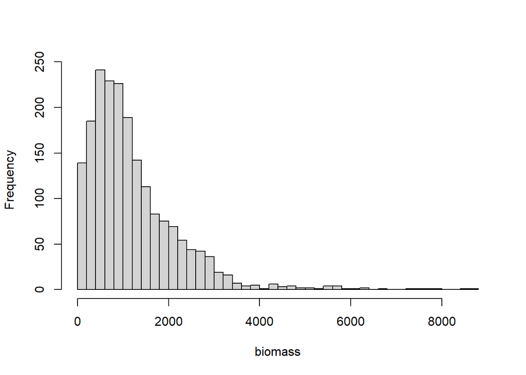

```r
#Similar to the density analysis, here I remove sites that have focused specifically on other invertebrates, or that unnaturally had no octocorals.
#omit_sites2 <- c("Red Dun Reef","Palmata Patch","Loggerhead Patch", "Texas Rock","Broward County A","Davis Rock")

# look at the frequency of biomass

hist(all_biomass$biomass, breaks=50, xlab = "biomass", main = NULL, freq = TRUE)
```

# Model selection - Check distribution

**Nbinom1 is preffrred**

```
## dropping columns from rank-deficient conditional model: HabitatP
```

```
## dropping columns from rank-deficient conditional model: HabitatP
```

```
## dropping columns from rank-deficient conditional model: HabitatP
```

```
## dropping columns from rank-deficient conditional model: HabitatP
```

```
## dropping columns from rank-deficient conditional model: HabitatP
## dropping columns from rank-deficient conditional model: HabitatP
```

```
##                              df       AIC
## poisson_glmm_full_model_2013 22 168774.24
## nbinom1_glmm_full_model_2013 23  27932.86
## nbinom_glmm_full_model_2013  23  28034.39
```

Model selection - All possible models

```r
nbinom1_glmm_full_model_2013 = glmmTMB(biomass ~ Year * Subregion +Depth+Habitat+(1|SiteID/StationID),
                                       family = nbinom1,
                                       data = all_biomass)
```

```
## dropping columns from rank-deficient conditional model: HabitatP
```

```r
nbinom1_glmm_full_model_2013 <- update(nbinom1_glmm_full_model_2013, control = glmmTMBControl(optCtrl=list(iter.max=1e3,eval.max=1e3)))
```

```
## dropping columns from rank-deficient conditional model: HabitatP
```

```r
nbinom_glmm_model_depthgroup_interaction_2013 <- glmmTMB(biomass ~ Year * Depth+ (1|SiteID/StationID),
                                                         family = nbinom1,
                                                         data = all_biomass)
#nbinom_glmm_model_depthgroup_interaction <- #update(nbinom_glmm_model_depthgroup_interaction, control = glmmTMBControl(optCtrl=list(iter.max=1e3,eval.max=1e3)))

nbinom_glmm_model_depthgroup_2013 <- glmmTMB(biomass ~ Year * Depth_group + (1|SiteID/StationID),
                                             family = nbinom1,
                                             data = all_biomass)
#nbinom_glmm_model_depthgroup <- update(nbinom_glmm_model_depthgroup, control = glmmTMBControl(optCtrl=list(iter.max=1e3,eval.max=1e3)))

nbinom_glmm_model_depth_2013 <- glmmTMB(biomass ~ Year + Depth + (1|SiteID/StationID),
                                        family = nbinom1,
                                        data = all_biomass)
nbinom_glmm_model_Subregion_2013 <- glmmTMB(biomass ~ Year * Subregion+(1|SiteID/StationID),
                                            family = nbinom1,
                                            data = all_biomass)
#nbinom_glmm_model_Subregion_2013 <- update(nbinom_glmm_model_Subregion_2013, control = glmmTMBControl(optCtrl=list(iter.max=1e3,eval.max=1e3)))

nbinom_glmm_model_Subregion2_2013 <- glmmTMB(biomass ~ Year + Subregion+(1|SiteID/StationID),
                                             family = nbinom1,
                                             data = all_biomass)
#  nbinom_glmm_model_Subregion2 <- update(nbinom_glmm_model_Subregion2, control = glmmTMBControl(optCtrl=list(iter.max=1e3,eval.max=1e3)))

nbinom_glmm_model_Subregion3_2013 <- glmmTMB(biomass ~ Year * Subregion+Depth + (1|SiteID/StationID),
                                             family = nbinom1,
                                             data = all_biomass)
nbinom_glmm_model_Subregion3_2013 <- update(nbinom_glmm_model_Subregion3_2013, control = glmmTMBControl(optCtrl=list(iter.max=1e3,eval.max=1e3)))
nbionom_glmm_model_ProjectRegion_2013 <- glmmTMB(biomass ~ Year * ProjectRegion+(1|SiteID/StationID),
                                                 family = nbinom1,
                                                 data = all_biomass)
#nbionom_glmm_model_ProjectRegion <- update(nbionom_glmm_model_ProjectRegion, control = glmmTMBControl(optCtrl=list(iter.max=1e3,eval.max=1e3)))

nbinom_glmm_model_ProjectRegion2_2013 <- glmmTMB(biomass ~ Year + ProjectRegion+(1|SiteID/StationID),
                                                 family = nbinom1,
                                                 data = all_biomass)
#nbinom_glmm_model_ProjectRegion2 <- update(nbinom_glmm_model_ProjectRegion2, control = glmmTMBControl(optCtrl=list(iter.max=1e3,eval.max=1e3)))

nbinom_glmm_model_ProjectRegion3_2013 <- glmmTMB(biomass ~ Year * ProjectRegion+Depth+(1|SiteID/StationID),
                                                 family = nbinom1,
                                                 data = all_biomass)
nbinom_glmm_model_ProjectRegion4_2013 <- glmmTMB(biomass ~ Year * ProjectRegion+Habitat+(1|SiteID/StationID),
                                                 family = nbinom1,
                                                 data = all_biomass)
```

```
## dropping columns from rank-deficient conditional model: HabitatP
```

```r
nbinom_glmm_model_Year_2013 <- glmmTMB(biomass ~ as.numeric(Year) + (1|SiteID/StationID),
                                       family = nbinom1,
                                       data = all_biomass)
#nbinom_glmm_model_Year <- update(nbinom_glmm_model_Year, control = glmmTMBControl(optCtrl=list(iter.max=1e3,eval.max=1e3)))


nbinom_glmm_model_habitat_2013 <- glmmTMB(biomass ~ Year * Habitat+(1|SiteID/StationID),
                                          family = nbinom1,
                                          data = all_biomass)
nbinom_glmm_model_habitat2_2013 <- glmmTMB(biomass ~ Year + Habitat+(1|SiteID/StationID),
                                           family = nbinom1,
                                           data = all_biomass)
nbinom_glmm_model_habitat3_2013 <- glmmTMB(biomass ~ Year + Habitat+Subregion+(1|SiteID/StationID),
                                           family = nbinom1,
                                           data = all_biomass)
```

```
## dropping columns from rank-deficient conditional model: SubregionUK
```

```r
nbinom_glmm_model_reg.hab_2013 <- glmmTMB(biomass ~ Year * Reg.Hab+(1|SiteID/StationID),
                                          family = nbinom1,
                                          data = all_biomass)
nbinom_glmm_model_null_2013 <- glmmTMB(biomass ~  + 1,
                                       family = nbinom1,
                                       data = all_biomass)

AICtab(nbinom1_glmm_full_model_2013,
       nbinom_glmm_model_depthgroup_interaction_2013,nbinom_glmm_model_depthgroup_2013,
       nbinom_glmm_model_depth_2013,
       nbinom_glmm_model_Subregion_2013,nbinom_glmm_model_Subregion2_2013, nbinom_glmm_model_Subregion3_2013,
       nbionom_glmm_model_ProjectRegion_2013,nbinom_glmm_model_ProjectRegion2_2013,
       nbinom_glmm_model_ProjectRegion3_2013,nbinom_glmm_model_ProjectRegion4_2013,
       nbinom_glmm_model_Year_2013,
       nbinom_glmm_model_habitat_2013,nbinom_glmm_model_habitat2_2013,nbinom_glmm_model_habitat3_2013,
       nbinom_glmm_model_null_2013, nbinom_glmm_model_reg.hab_2013)
```

```
##                                               dAIC   df
## nbinom_glmm_model_Subregion3_2013                0.0 18
## nbinom1_glmm_full_model_2013                     1.0 23
## nbinom_glmm_model_Subregion_2013                12.2 17
## nbinom_glmm_model_depthgroup_2013               83.8 11
## nbinom_glmm_model_depthgroup_interaction_2013   99.4 7
## nbinom_glmm_model_reg.hab_2013                 107.1 23
## nbinom_glmm_model_habitat_2013                 115.0 17
## nbinom_glmm_model_ProjectRegion3_2013          122.8 12
## nbinom_glmm_model_ProjectRegion4_2013          128.2 16
## nbinom_glmm_model_depth_2013                   130.3 6
## nbionom_glmm_model_ProjectRegion_2013          132.9 11
## nbinom_glmm_model_ProjectRegion2_2013          135.6 8
## nbinom_glmm_model_habitat3_2013                136.2 16
## nbinom_glmm_model_habitat2_2013                141.0 11
## nbinom_glmm_model_Year_2013                    141.6 5
## nbinom_glmm_model_Subregion2_2013              142.7 11
## nbinom_glmm_model_null_2013                   3691.2 2
```

```r
BICtab(nbinom1_glmm_full_model_2013,
    nbinom_glmm_model_depthgroup_interaction_2013,nbinom_glmm_model_depthgroup_2013,
    nbinom_glmm_model_depth_2013,
    nbinom_glmm_model_Subregion_2013,nbinom_glmm_model_Subregion2_2013, nbinom_glmm_model_Subregion3_2013,
    nbionom_glmm_model_ProjectRegion_2013,nbinom_glmm_model_ProjectRegion2_2013,
    nbinom_glmm_model_ProjectRegion3_2013,nbinom_glmm_model_ProjectRegion4_2013,
    nbinom_glmm_model_Year_2013,
    nbinom_glmm_model_habitat_2013,nbinom_glmm_model_habitat2_2013,nbinom_glmm_model_habitat3_2013,
    nbinom_glmm_model_null_2013, nbinom_glmm_model_reg.hab_2013)
```

```
##                                               dBIC   df
## nbinom_glmm_model_Subregion3_2013                0.0 18
## nbinom_glmm_model_Subregion_2013                 6.6 17
## nbinom1_glmm_full_model_2013                    28.9 23
## nbinom_glmm_model_depthgroup_interaction_2013   38.0 7
## nbinom_glmm_model_depthgroup_2013               44.8 11
## nbinom_glmm_model_depth_2013                    63.3 6
## nbinom_glmm_model_Year_2013                     69.1 5
## nbinom_glmm_model_ProjectRegion2_2013           79.9 8
## nbinom_glmm_model_ProjectRegion3_2013           89.4 12
## nbionom_glmm_model_ProjectRegion_2013           93.8 11
## nbinom_glmm_model_habitat2_2013                101.9 11
## nbinom_glmm_model_Subregion2_2013              103.7 11
## nbinom_glmm_model_habitat_2013                 109.5 17
## nbinom_glmm_model_ProjectRegion4_2013          117.0 16
## nbinom_glmm_model_habitat3_2013                125.1 16
## nbinom_glmm_model_reg.hab_2013                 135.0 23
## nbinom_glmm_model_null_2013                   3602.0 2
```

BEST MODEL = Year*Subregion+Depth , According to AIC and BIC. Notice, The full model is not far behind. However, simplicity is also important and I will procedd with model_Subregion3.

```
##  Family: nbinom1  ( log )
## Formula:          biomass ~ Year * Subregion + Depth + (1 | SiteID/StationID)
## Data: all_biomass
##
##      AIC      BIC   logLik deviance df.resid
##  27931.9  28032.3 -13947.9  27895.9     1938
##
## Random effects:
##
## Conditional model:
##  Groups           Name        Variance Std.Dev.
##  StationID:SiteID (Intercept) 0.09744  0.3121
##  SiteID           (Intercept) 0.49394  0.7028
## Number of obs: 1956, groups:  StationID:SiteID, 179; SiteID, 45
##
## Dispersion parameter for nbinom1 family (): 95.8
##
## Conditional model:
##                     Estimate Std. Error z value Pr(>|z|)
## (Intercept)        4.537e+00  1.628e+01   0.279 0.780525
## Year               1.346e-03  8.068e-03   0.167 0.867523
## SubregionDC       -7.109e+01  1.981e+01  -3.589 0.000331 ***
## SubregionDT       -2.096e+01  2.001e+01  -1.048 0.294652
## SubregionLK        2.797e+01  1.934e+01   1.446 0.148205
## SubregionMK        1.474e+01  1.830e+01   0.805 0.420712
## SubregionPBC      -5.112e+01  2.156e+01  -2.371 0.017733 *
## SubregionUK       -1.061e+02  1.864e+01  -5.688 1.28e-08 ***
## Depth             -2.514e-02  6.455e-03  -3.895 9.83e-05 ***
## Year:SubregionDC   3.535e-02  9.812e-03   3.603 0.000315 ***
## Year:SubregionDT   1.033e-02  9.911e-03   1.042 0.297243
## Year:SubregionLK  -1.358e-02  9.583e-03  -1.417 0.156603
## Year:SubregionMK  -6.902e-03  9.068e-03  -0.761 0.446573
## Year:SubregionPBC  2.588e-02  1.068e-02   2.424 0.015356 *
## Year:SubregionUK   5.261e-02  9.236e-03   5.696 1.22e-08 ***
## ---
## Signif. codes:  0 '***' 0.001 '**' 0.01 '*' 0.05 '.' 0.1 ' ' 1
```

```
## # R2 for Mixed Models
##
##   Conditional R2: 0.897
##      Marginal R2: 0.310
```

# Diagnosis of warnings

The best model is still ok, no major errors were identifyied.

```r
diagnose(best_mod)
```

```
## Unusually large coefficients (|x|>10):
##
##  SubregionDC  SubregionDT  SubregionLK  SubregionMK SubregionPBC  SubregionUK
##    -71.09311    -20.96485     27.96751     14.73699    -51.11540   -106.05640
##
## Large negative coefficients in zi (log-odds of zero-inflation),
## dispersion, or random effects (log-standard deviations) suggest
## unnecessary components (converging to zero on the constrained scale);
## large negative and/or positive components in binomial or Poisson
## conditional parameters suggest (quasi-)complete separation. Large
## values of nbinom2 dispersion suggest that you should use a Poisson
## model instead.
##
##
## Unusually large Z-statistics (|x|>5):
##
##                SubregionUK           Year:SubregionUK
##                  -5.688357                   5.696366
##              d~(Intercept) theta_1|StationID:SiteID.1
##                 130.919355                 -15.854881
##
## Large Z-statistics (estimate/std err) suggest a *possible* failure of
## the Wald approximation - often also associated with parameters that are
## at or near the edge of their range (e.g. random-effects standard
## deviations approaching 0).  (Alternately, they may simply represent
## very well-estimated parameters; intercepts of non-centered models may
## fall in this category.) While the Wald p-values and standard errors
## listed in summary() may be unreliable, profile confidence intervals
## (see ?confint.glmmTMB) and likelihood ratio test p-values derived by
## comparing models (e.g. ?drop1) are probably still OK.  (Note that the
## LRT is conservative when the null value is on the boundary, e.g. a
## variance or zero-inflation value of 0 (Self and Liang 1987; Stram and
## Lee 1994; Goldman and Whelan 2000); in simple cases these p-values are
## approximately twice as large as they should be.)
```

# Model Validation - **Visualizing residuals**

This model has issues with uniformity (ks test). Outliars also problematic, but not after testing using boostrapping. So really the Uniformity is an issue.

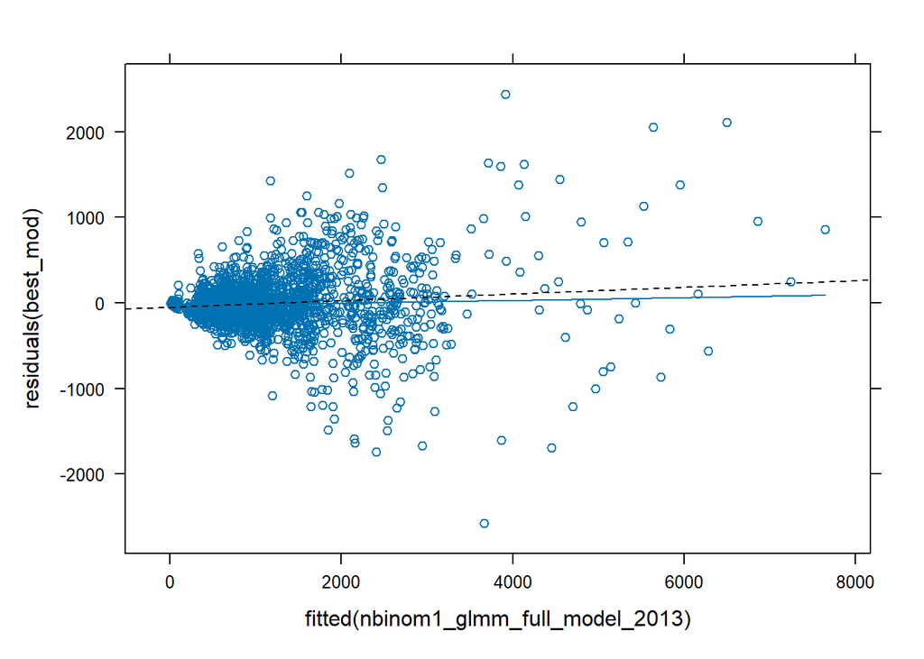

```
## DHARMa:testOutliers with type = binomial may have inflated Type I error rates for integer-valued distributions. To get a more exact result, it is recommended to re-run testOutliers with type = 'bootstrap'. See ?testOutliers for details
```

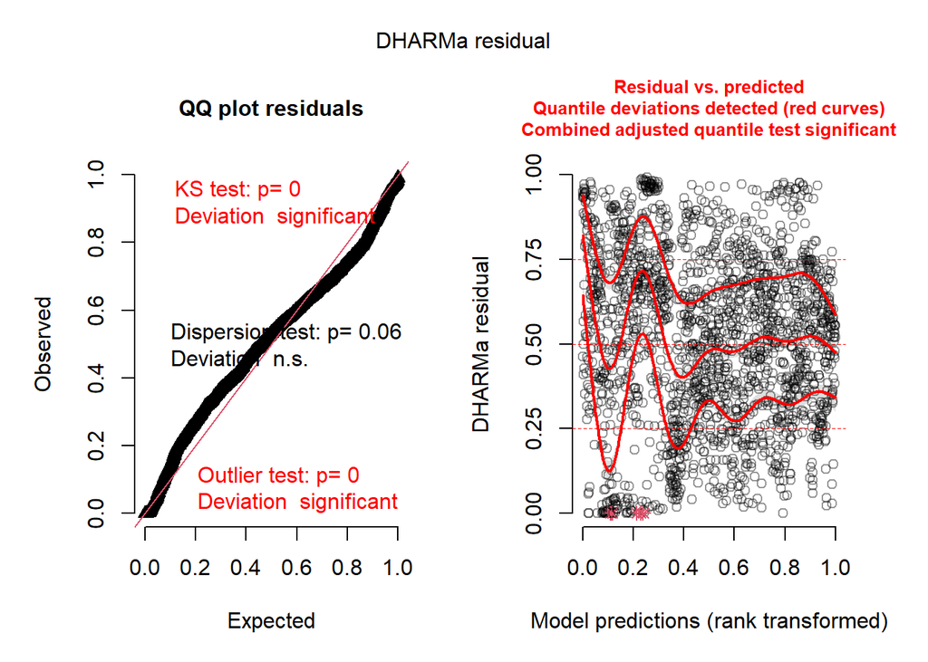

```r
simulationOutput <- simulateResiduals(best_mod, n = 1000, plot = TRUE,quantreg = T)
```

```r
  testDispersion(simulationOutput) #dispersion fine, but just margnially
```

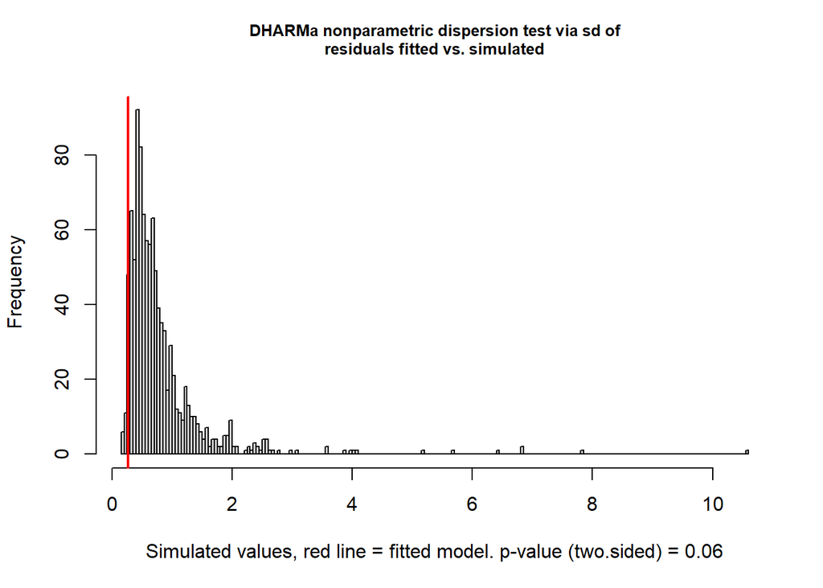

```
##
##  DHARMa nonparametric dispersion test via sd of residuals fitted vs.
##  simulated
##
## data:  simulationOutput
## dispersion = 0.33434, p-value = 0.06
## alternative hypothesis: two.sided
```

```r
  testOutliers(simulationOutput, type = "bootstrap")
```

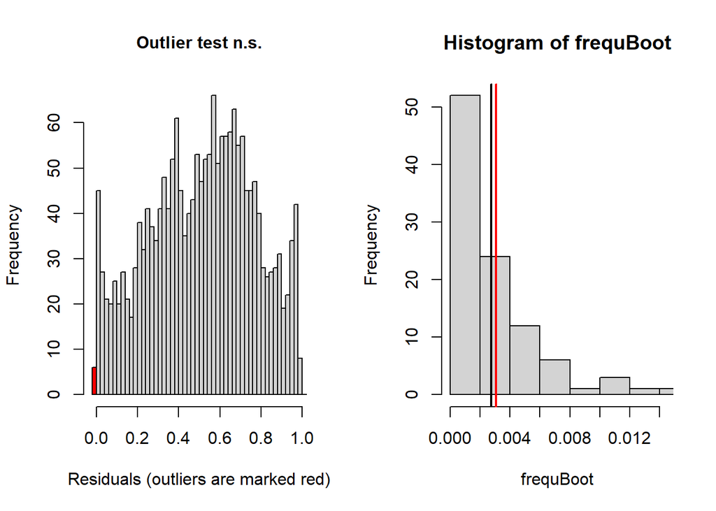

```
##
##  DHARMa bootstrapped outlier test
##
## data:  simulationOutput
## outliers at both margin(s) = 6, observations = 1956, p-value = 0.78
## alternative hypothesis: two.sided
##  percent confidence interval:
##  0.0000000 0.0107362
## sample estimates:
## outlier frequency (expected: 0.00273517382413088 )
##                                        0.003067485
```

```r
  testResiduals(simulationOutput)
```

```
## DHARMa:testOutliers with type = binomial may have inflated Type I error rates for integer-valued distributions. To get a more exact result, it is recommended to re-run testOutliers with type = 'bootstrap'. See ?testOutliers for details
## DHARMa:testOutliers with type = binomial may have inflated Type I error rates for integer-valued distributions. To get a more exact result, it is recommended to re-run testOutliers with type = 'bootstrap'. See ?testOutliers for details
```

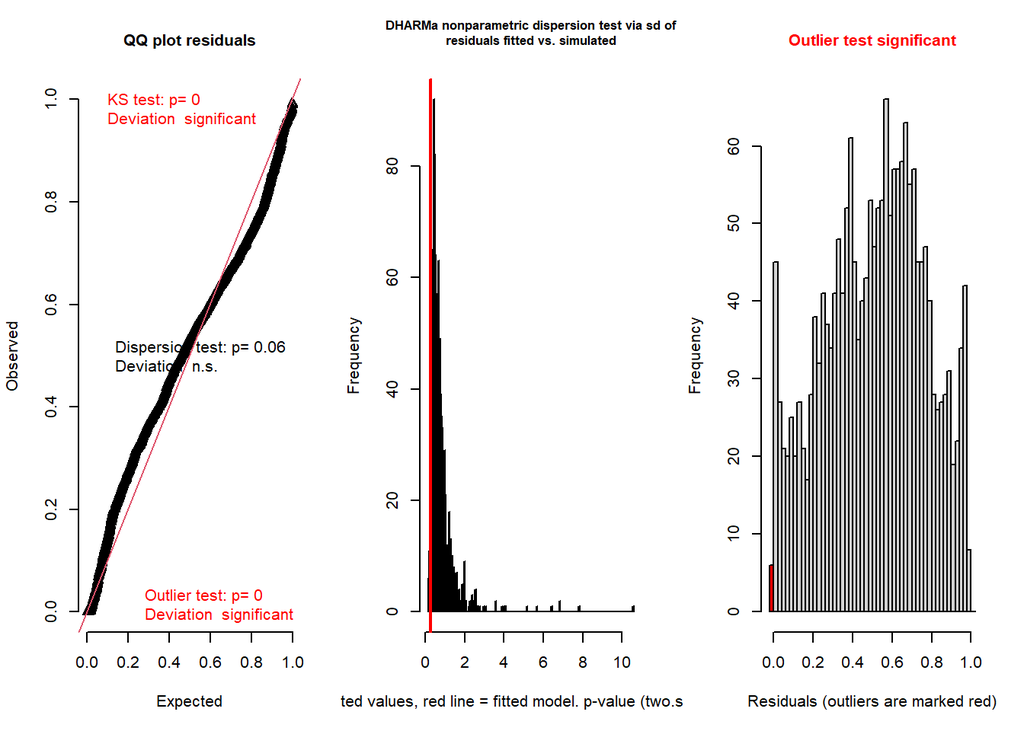

```
## $uniformity
##
##  Asymptotic one-sample Kolmogorov-Smirnov test
##
## data:  simulationOutput$scaledResiduals
## D = 0.079271, p-value = 4.216e-11
## alternative hypothesis: two-sided
##
##
## $dispersion
##
##  DHARMa nonparametric dispersion test via sd of residuals fitted vs.
##  simulated
##
## data:  simulationOutput
## dispersion = 0.33434, p-value = 0.06
## alternative hypothesis: two.sided
##
##
## $outliers
##
##  DHARMa outlier test based on exact binomial test with approximate
##  expectations
##
## data:  simulationOutput
## outliers at both margin(s) = 23, observations = 1956, p-value =
## 3.492e-11
## alternative hypothesis: true probability of success is not equal to 0.001998002
## 95 percent confidence interval:
##  0.007468201 0.017591850
## sample estimates:
## frequency of outliers (expected: 0.001998001998002 )
##                                           0.01175869
```

[output not shown]

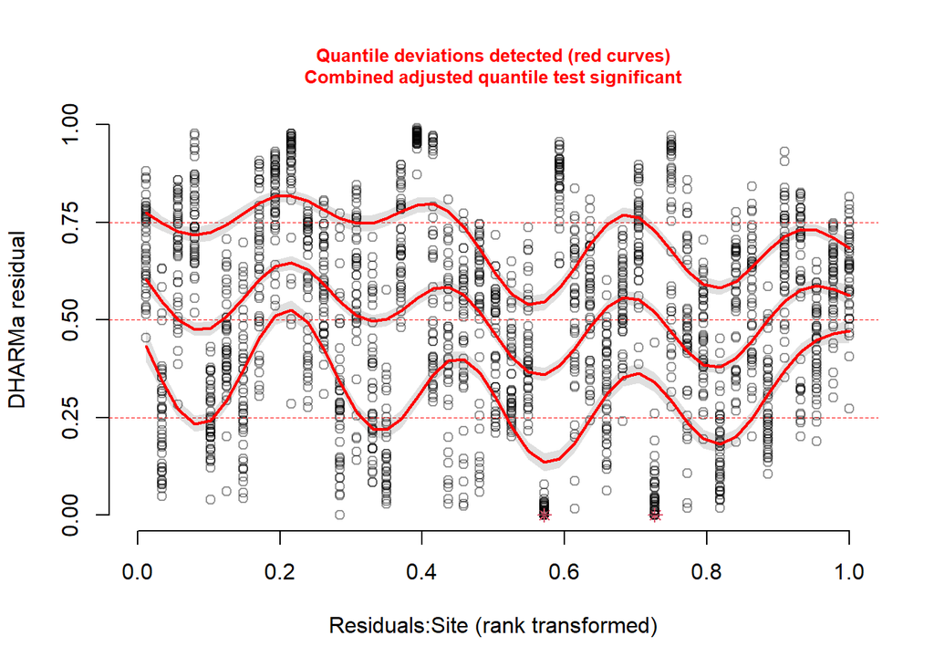

```r
  plotResiduals(simulationOutput, all_biomass$SiteID, xlab = "Residuals:Site", main=NULL)
```

# Data visualization

Looking at the data per site.

Although I didnt plot Year here, I can not find major outliars in the raw data. maybe except for two sites. I check them as well, the data is ok.

```r
to_keep <- c("ProjectRegion", "Habitat","Reg.Hab", "Depth","Depth_group")


Biomass_per_site <- all_biomass %>%
  group_by(Year, Subregion, SiteID) %>%
  summarize(
    mean_biomass = mean(biomass, na.rm = TRUE),
    sd_biomass = sd(biomass, na.rm = TRUE),
    n = n(),
    across(all_of(to_keep), ~first(.)),
    .groups = "drop"
  )

head(Biomass_per_site)
```

```
## # A tibble: 6 × 11
##    Year Subregion SiteID mean_biomass sd_biomass     n ProjectRegion Habitat
##   <int> <fct>      <int>        <dbl>      <dbl> <int> <fct>         <fct>
## 1  2013 BC             1         365       147.      4 SECREMP       Inner
## 2  2013 BC             2         659.      171.      4 SECREMP       Middle
## 3  2013 BC             3        1124.      431.      4 SECREMP       Outer
## 4  2013 BC            87         192.       57.7     4 SECREMP       Nearshore
## 5  2013 BC            88         520.      150.      4 SECREMP       Middle
## 6  2013 BC            89         497       102.      4 SECREMP       Outer
## # ℹ 3 more variables: Reg.Hab <fct>, Depth <int>, Depth_group <fct>
```

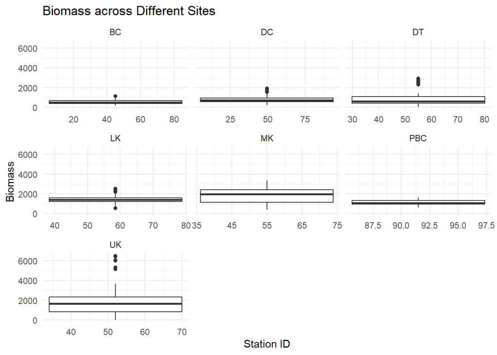

```r
p1 <- ggplot(Biomass_per_site, aes(x=SiteID,y = mean_biomass)) +
  geom_boxplot() +
  facet_wrap(~ Subregion, scales = "free_x") +
  labs(title = "Biomass across Different Sites", x = "Station ID", y = "Biomass") +
  theme_minimal()
p1
```

# Modeling with biomass averaged per site

This might have reduced the uniformity by a little bit, but didnt resolve it completly. Still unsure this is what I need.

```r
Biomass_per_site_filter <- Biomass_per_site %>%
  filter(!(n <3)
)

glimpse(Biomass_per_site)
```

```
## Rows: 493
## Columns: 11
## $ Year          <int> 2013, 2013, 2013, 2013, 2013, 2013, 2013, 2013, 2013, 20…
## $ Subregion     <fct> BC, BC, BC, BC, BC, BC, DC, DC, DC, DC, DC, DC, DC, DC, …
## $ SiteID        <int> 1, 2, 3, 87, 88, 89, 0, 4, 5, 6, 91, 92, 93, 99, 27, 41,…
## $ mean_biomass  <dbl> 365.0000, 658.7500, 1124.2500, 192.5000, 519.7500, 497.0…
## $ sd_biomass    <dbl> 147.21413, 170.61335, 431.41965, 57.68015, 150.40252, 10…
## $ n             <int> 4, 4, 4, 4, 4, 4, 4, 4, 4, 4, 4, 4, 4, 4, 4, 4, 3, 4, 4,…
## $ ProjectRegion <fct> SECREMP, SECREMP, SECREMP, SECREMP, SECREMP, SECREMP, SE…
## $ Habitat       <fct> Inner, Middle, Outer, Nearshore, Middle, Outer, Inner, N…
## $ Reg.Hab       <fct> SECREMP _ Inner, SECREMP _ Middle, SECREMP _ Outer, SECR…
## $ Depth         <int> 25, 45, 55, 25, 40, 55, 24, 20, 60, 15, 25, 45, 55, 41, …
## $ Depth_group   <fct> Mid-shallow, Deep, Deep, Mid-shallow, Mid-deep, Deep, Mi…
```

```r
##
mod_Subregion3_2013 <- glmmTMB(mean_biomass ~ Year * Subregion+Depth + (1|SiteID),
                                             family = nbinom1,
                                             data = Biomass_per_site)
```

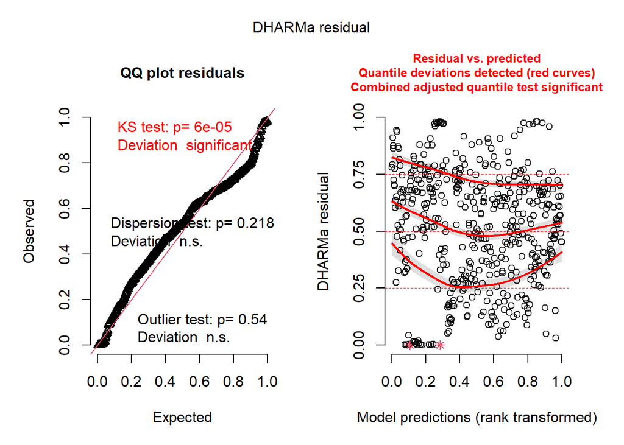

```r
simulationOutput2 <- simulateResiduals(mod_Subregion3_2013, n = 1000, plot = TRUE,quantreg = T)
```

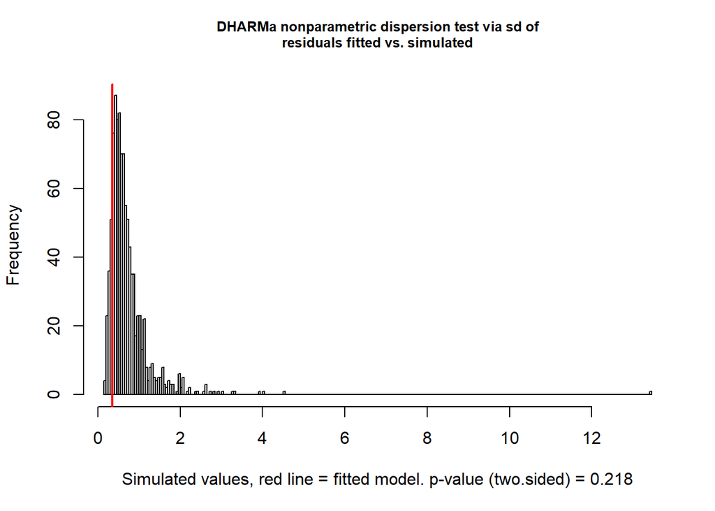

```
##
##  DHARMa nonparametric dispersion test via sd of residuals fitted vs.
##  simulated
##
## data:  simulationOutput
## dispersion = 0.47667, p-value = 0.218
## alternative hypothesis: two.sided
```

```r
testDispersion(simulationOutput2) #dispersion fine, but just margnially
```

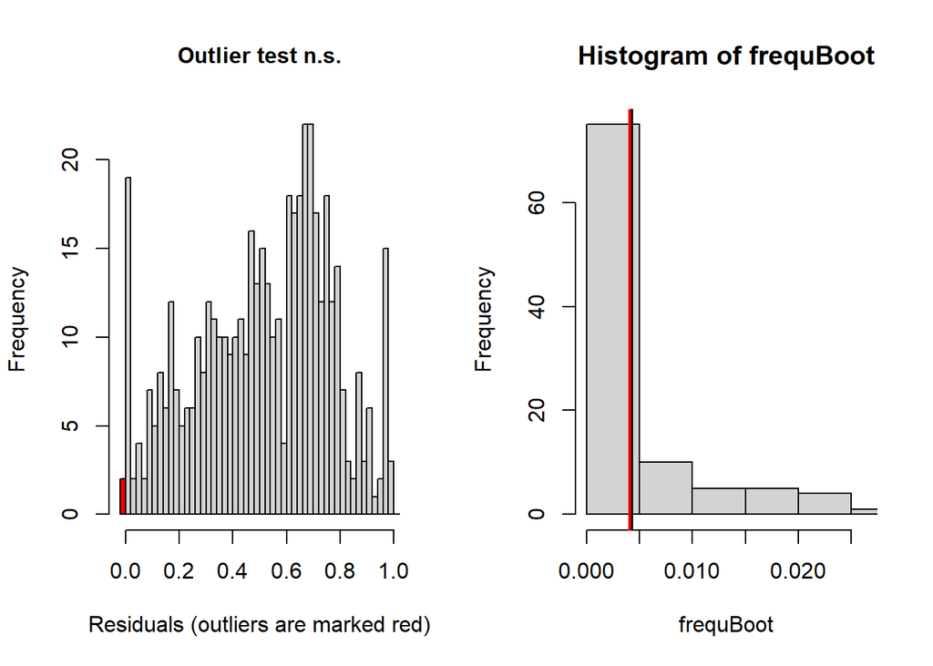

```
##
##  DHARMa bootstrapped outlier test
##
## data:  simulationOutput2
## outliers at both margin(s) = 2, observations = 493, p-value = 0.7
## alternative hypothesis: two.sided
##  percent confidence interval:
##  0.00000000 0.02337728
## sample estimates:
## outlier frequency (expected: 0.00427991886409736 )
##                                        0.004056795
```

```r
testOutliers(simulationOutput2, type = "bootstrap")
```

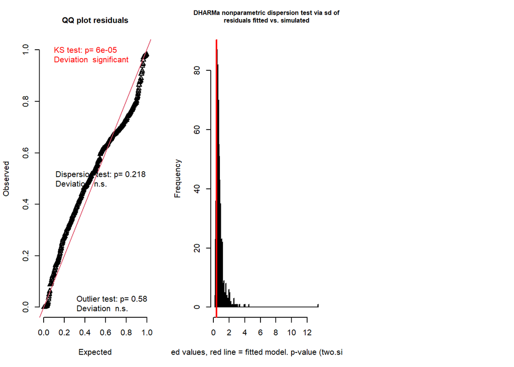

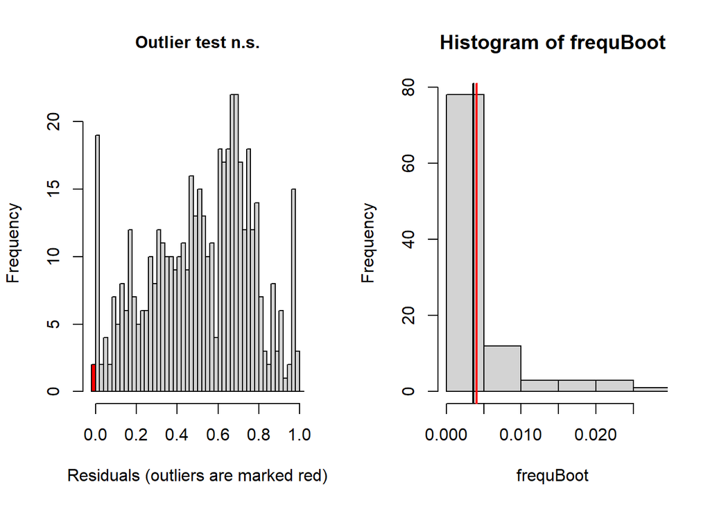

```
## $uniformity
##
##  Asymptotic one-sample Kolmogorov-Smirnov test
##
## data:  simulationOutput$scaledResiduals
## D = 0.10258, p-value = 6.238e-05
## alternative hypothesis: two-sided
##
##
## $dispersion
##
##  DHARMa nonparametric dispersion test via sd of residuals fitted vs.
##  simulated
##
## data:  simulationOutput
## dispersion = 0.47667, p-value = 0.218
## alternative hypothesis: two.sided
##
##
## $outliers
##
##  DHARMa bootstrapped outlier test
##
## data:  simulationOutput
## outliers at both margin(s) = 2, observations = 493, p-value = 0.58
## alternative hypothesis: two.sided
##  percent confidence interval:
##  0.00000000 0.02337728
## sample estimates:
## outlier frequency (expected: 0.0036105476673428 )
##                                       0.004056795
```

[output not shown]

```r
testResiduals(simulationOutput2)
```

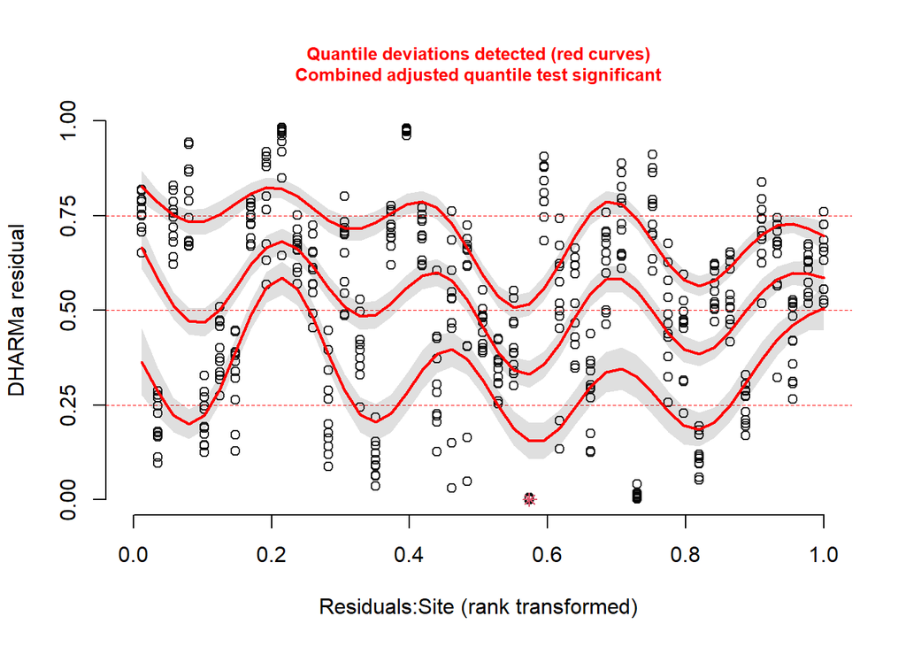

```r
plotResiduals(simulationOutput2, Biomass_per_site$SiteID, xlab = "Residuals:Site", main=NULL)
```